# Determining Category of Individuals With the Longest Ford GO-Bike Ride Duration

## by Joshua Oshla Olaku

## Investigation Overview

> In the process of ivestigating this data, I wanted to have insight as to which category of inviduals (whether male or female, subscriber or customer) have the longest ride durations and at which time of the day and day of the week they take this rides, and also to where of from where.

## Dataset Overview

> The Ford Go-Bike dataset consists of the durations in seconds of bike rides taken by riders and also their birth date information, stations riders started from and ended, user type and other information. the dataset initially had 183,412 rows of data which was later cleaned and cutdown to 175,147 rows due to some missing data. The dataset contained the information on users of Ford Go-bike share such as their ride durations, their gender, user type, birth dates, start station and end station information, etc. These were investigated to have an insight as to which category of people usually take the longests rides.

## Distribution of Ride Durations

> After applying a log transformation scale to the durations column of the dataset a bell curve or normal distribution with a slight skew to the right is seen across duration of rides data which takes on a range of values of between 61 seconds to about 6,974 seconds (1 minute to about 2 hours).

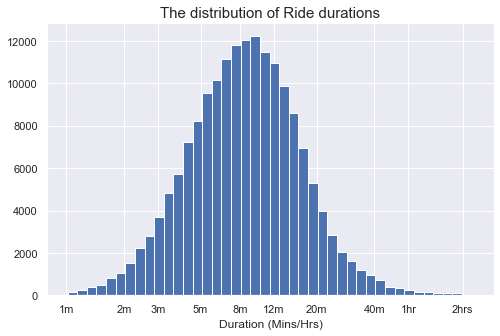

## Age distibution of Bike Users

> The age of riders ranged from the age of 20 years to above 70. The ages above 70 were considered as outliers for the sake of this exploration and only those ages between 20 and 70 were included in the analysis. A new column for age was created in the dataset which was calculated from the birth years of the bike users. This plot shows a skew to the right which suggests that there are less number of bike riders with increasing age. The peak or highest number of riders falls around individuals of the ages 26 and 32.

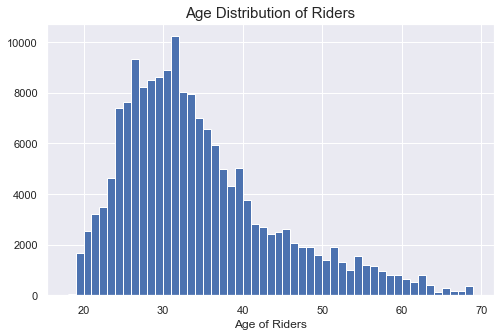

## Day and Time vs Duration of Rides

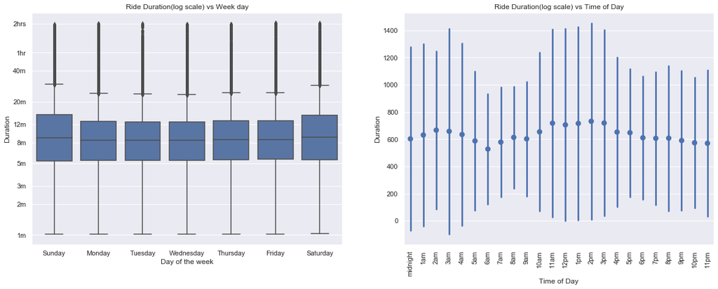

# Ride Duration by Gender and User Type

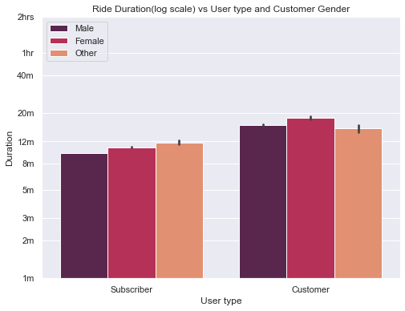

# Ride Duration vs Time of Day and Gender

> As seen below, the longest ride durations are associated with females which takes place most often at 2am.

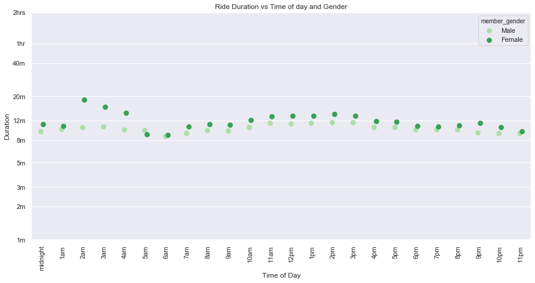